# On understanding and manipulating the hatching patterns of Diabrotica v. virgifera (Coleoptera: Chrysomelidae) eggs to improve the design of experiments

### 3.4.2. Hatch end statistics

The general response of the hatching end was affected by the the different time length spent in diapause and the different incubation temperatures.

```r
gamhe <- mgcv::gam(hatchend ~ s(DiapMonths) + TempCf -1,
                   data = hatchtableNoND)

anova(gamhe)
```

```
##
## Family: gaussian
## Link function: identity
##
## Formula:
## hatchend ~ s(DiapMonths) + TempCf - 1
##
## Parametric Terms:
##        df    F p-value
## TempCf  3 2560  <2e-16
##
## Approximate significance of smooth terms:
##                 edf Ref.df     F p-value
## s(DiapMonths) 8.029  8.753 124.4  <2e-16
```

```r
# plot(gamhe)
# mgcv::gam.check(gamhe)

multgamhe <- glht(gamhe, linfct =c('TempCf16 - TempCf20 == 0',
                                   'TempCf16 - TempCf24 == 0',
                                   'TempCf20 - TempCf24 == 0'))
summary(multgamhe)
```

```
##
##   Simultaneous Tests for General Linear Hypotheses
##
## Fit: mgcv::gam(formula = hatchend ~ s(DiapMonths) + TempCf - 1, data = hatchtableNoND)
##
## Linear Hypotheses:
##                          Estimate Std. Error z value Pr(>|z|)
## TempCf16 - TempCf20 == 0   39.798      1.952  20.385   <1e-10 ***
## TempCf16 - TempCf24 == 0   53.026      1.952  27.169   <1e-10 ***
## TempCf20 - TempCf24 == 0   13.228      1.901   6.957   <1e-10 ***
## ---
## Signif. codes:  0 '***' 0.001 '**' 0.01 '*' 0.05 '.' 0.1 ' ' 1
## (Adjusted p values reported -- single-step method)
```

```r
confint(multgamhe)$confint
```

```
##                     Estimate       lwr      upr
## TempCf16 - TempCf20 39.79757 35.221273 44.37387
## TempCf16 - TempCf24 53.02567 48.450769 57.60058
## TempCf20 - TempCf24 13.22810  8.771118 17.68509
## attr(,"conf.level")
## [1] 0.95
## attr(,"calpha")
## [1] 2.344034
```

The pairwise comparisons of the different length CSE categories within the corresponding incubation temperature (not between them!) for hatching end. 1. F statistics and compact letter display format between the categories. 2. Estimate, Std. Error, t-values and p-values above for all categories comparisons.

First, for the 24C incubated CSE eggs

```r
hatchend24cld <- ModelDiap("hatchend", 24)
```

```
## F statistics
##     value     numdf     dendf
##  50.05947   7.00000 140.00000
## All pairwise comparisons, with compact letter display
##           0 0.5 to 1.5m     2 to 4m     5 to 7m    8 to 10m   11 to 13m
##         "d"         "c"         "b"         "a"         "a"         "a"
##   14 to 16m 17m or more
##        "ab"        "ab"
##
##   Simultaneous Tests for General Linear Hypotheses
##
## Multiple Comparisons of Means: Tukey Contrasts
##
##
## Fit: lm(formula = formula0, data = df)
##
## Linear Hypotheses:
##                                 Estimate Std. Error t value Pr(>|t|)
## 0.5 to 1.5m - 0 == 0           -39.13333    6.78173  -5.770   <0.001 ***
## 2 to 4m - 0 == 0               -62.04242    6.30240  -9.844   <0.001 ***
## 5 to 7m - 0 == 0               -81.55758    6.30240 -12.941   <0.001 ***
## 8 to 10m - 0 == 0              -86.97857    6.37601 -13.642   <0.001 ***
## 11 to 13m - 0 == 0             -86.88000    6.43371 -13.504   <0.001 ***
## 14 to 16m - 0 == 0             -75.55000    7.48682 -10.091   <0.001 ***
## 17m or more - 0 == 0           -82.80000   14.38621  -5.756   <0.001 ***
## 2 to 4m - 0.5 to 1.5m == 0     -22.90909    4.08953  -5.602   <0.001 ***
## 5 to 7m - 0.5 to 1.5m == 0     -42.42424    4.08953 -10.374   <0.001 ***
## 8 to 10m - 0.5 to 1.5m == 0    -47.84524    4.20209 -11.386   <0.001 ***
## 11 to 13m - 0.5 to 1.5m == 0   -47.74667    4.28914 -11.132   <0.001 ***
## 14 to 16m - 0.5 to 1.5m == 0   -36.41667    5.74949  -6.334   <0.001 ***
## 17m or more - 0.5 to 1.5m == 0 -43.66667   13.56345  -3.219   0.0274 *
## 5 to 7m - 2 to 4m == 0         -19.51515    3.23306  -6.036   <0.001 ***
## 8 to 10m - 2 to 4m == 0        -24.93615    3.37431  -7.390   <0.001 ***
## 11 to 13m - 2 to 4m == 0       -24.83758    3.48211  -7.133   <0.001 ***
## 14 to 16m - 2 to 4m == 0       -13.50758    5.17542  -2.610   0.1389
## 17m or more - 2 to 4m == 0     -20.75758   13.33025  -1.557   0.7450
## 8 to 10m - 5 to 7m == 0         -5.42100    3.37431  -1.607   0.7137
## 11 to 13m - 5 to 7m == 0        -5.32242    3.48211  -1.529   0.7623
## 14 to 16m - 5 to 7m == 0         6.00758    5.17542   1.161   0.9305
## 17m or more - 5 to 7m == 0      -1.24242   13.33025  -0.093   1.0000
## 11 to 13m - 8 to 10m == 0        0.09857    3.61364   0.027   1.0000
## 14 to 16m - 8 to 10m == 0       11.42857    5.26482   2.171   0.3388
## 17m or more - 8 to 10m == 0      4.17857   13.36521   0.313   1.0000
## 14 to 16m - 11 to 13m == 0      11.33000    5.33455   2.124   0.3668
## 17m or more - 11 to 13m == 0     4.08000   13.39284   0.305   1.0000
## 17m or more - 14 to 16m == 0    -7.25000   13.92939  -0.520   0.9994
## ---
## Signif. codes:  0 '***' 0.001 '**' 0.01 '*' 0.05 '.' 0.1 ' ' 1
## (Adjusted p values reported -- single-step method)
```

Second, for the lowest, 16C incubated CSE eggs

```r
hatchend16cld <- ModelDiap("hatchend", 16)
```

```
## F statistics
##     value     numdf     dendf
##  84.07794   7.00000 125.00000
## All pairwise comparisons, with compact letter display
##           0 0.5 to 1.5m     2 to 4m     5 to 7m    8 to 10m   11 to 13m
##         "e"         "d"         "c"        "ab"         "a"        "ab"
##   14 to 16m 17m or more
##         "b"        "ab"
##
##   Simultaneous Tests for General Linear Hypotheses
##
## Multiple Comparisons of Means: Tukey Contrasts
##
##
## Fit: lm(formula = formula0, data = df)
##
## Linear Hypotheses:
##                                Estimate Std. Error t value Pr(>|t|)
## 0.5 to 1.5m - 0 == 0            -35.238      8.160  -4.319  < 0.001 ***
## 2 to 4m - 0 == 0                -61.315      7.547  -8.124  < 0.001 ***
## 5 to 7m - 0 == 0               -109.732      7.666 -14.315  < 0.001 ***
## 8 to 10m - 0 == 0              -120.425      7.458 -16.146  < 0.001 ***
## 11 to 13m - 0 == 0             -113.949      7.666 -14.865  < 0.001 ***
## 14 to 16m - 0 == 0              -93.917      9.031 -10.399  < 0.001 ***
## 17m or more - 0 == 0           -119.167     18.062  -6.598  < 0.001 ***
## 2 to 4m - 0.5 to 1.5m == 0      -26.077      5.507  -4.735  < 0.001 ***
## 5 to 7m - 0.5 to 1.5m == 0      -74.494      5.668 -13.142  < 0.001 ***
## 8 to 10m - 0.5 to 1.5m == 0     -85.187      5.385 -15.820  < 0.001 ***
## 11 to 13m - 0.5 to 1.5m == 0    -78.711      5.668 -13.886  < 0.001 ***
## 14 to 16m - 0.5 to 1.5m == 0    -58.679      7.411  -7.917  < 0.001 ***
## 17m or more - 0.5 to 1.5m == 0  -83.929     17.309  -4.849  < 0.001 ***
## 5 to 7m - 2 to 4m == 0          -48.417      4.745 -10.204  < 0.001 ***
## 8 to 10m - 2 to 4m == 0         -59.110      4.402 -13.428  < 0.001 ***
## 11 to 13m - 2 to 4m == 0        -52.634      4.745 -11.093  < 0.001 ***
## 14 to 16m - 2 to 4m == 0        -32.602      6.731  -4.843  < 0.001 ***
## 17m or more - 2 to 4m == 0      -57.852     17.029  -3.397  0.01647 *
## 8 to 10m - 5 to 7m == 0         -10.693      4.602  -2.324  0.26011
## 11 to 13m - 5 to 7m == 0         -4.217      4.931  -0.855  0.98715
## 14 to 16m - 5 to 7m == 0         15.815      6.864   2.304  0.26935
## 17m or more - 5 to 7m == 0       -9.435     17.082  -0.552  0.99915
## 11 to 13m - 8 to 10m == 0         6.475      4.602   1.407  0.83214
## 14 to 16m - 8 to 10m == 0        26.508      6.631   3.997  0.00217 **
## 17m or more - 8 to 10m == 0       1.258     16.990   0.074  1.00000
## 14 to 16m - 11 to 13m == 0       20.033      6.864   2.919  0.06650 .
## 17m or more - 11 to 13m == 0     -5.217     17.082  -0.305  0.99998
## 17m or more - 14 to 16m == 0    -25.250     17.737  -1.424  0.82394
## ---
## Signif. codes:  0 '***' 0.001 '**' 0.01 '*' 0.05 '.' 0.1 ' ' 1
## (Adjusted p values reported -- single-step method)
```

Third, for the 20C incubated CSE eggs

```r
hatchend20cld <- ModelDiap("hatchend", 20)
```

```
## F statistics
##     value     numdf     dendf
##  46.29557   6.00000 140.00000
## All pairwise comparisons, with compact letter display
##           0 0.5 to 1.5m     2 to 4m     5 to 7m    8 to 10m   11 to 13m
##         "d"         "c"         "b"         "a"         "a"         "a"
##   14 to 16m
##        "ab"
##
##   Simultaneous Tests for General Linear Hypotheses
##
## Multiple Comparisons of Means: Tukey Contrasts
##
##
## Fit: lm(formula = formula0, data = df)
##
## Linear Hypotheses:
##                              Estimate Std. Error t value Pr(>|t|)
## 0.5 to 1.5m - 0 == 0         -38.6723     7.4813  -5.169  < 0.001 ***
## 2 to 4m - 0 == 0             -67.3304     6.9511  -9.686  < 0.001 ***
## 5 to 7m - 0 == 0             -85.2967     7.0936 -12.025  < 0.001 ***
## 8 to 10m - 0 == 0            -89.4532     7.0153 -12.751  < 0.001 ***
## 11 to 13m - 0 == 0           -88.7500     7.0396 -12.607  < 0.001 ***
## 14 to 16m - 0 == 0           -73.5179     8.6217  -8.527  < 0.001 ***
## 2 to 4m - 0.5 to 1.5m == 0   -28.6581     4.9997  -5.732  < 0.001 ***
## 5 to 7m - 0.5 to 1.5m == 0   -46.6244     5.1960  -8.973  < 0.001 ***
## 8 to 10m - 0.5 to 1.5m == 0  -50.7809     5.0886  -9.979  < 0.001 ***
## 11 to 13m - 0.5 to 1.5m == 0 -50.0777     5.1221  -9.777  < 0.001 ***
## 14 to 16m - 0.5 to 1.5m == 0 -34.8456     7.1424  -4.879  < 0.001 ***
## 5 to 7m - 2 to 4m == 0       -17.9663     4.3984  -4.085  0.00121 **
## 8 to 10m - 2 to 4m == 0      -22.1228     4.2710  -5.180  < 0.001 ***
## 11 to 13m - 2 to 4m == 0     -21.4196     4.3109  -4.969  < 0.001 ***
## 14 to 16m - 2 to 4m == 0      -6.1875     6.5850  -0.940  0.96297
## 8 to 10m - 5 to 7m == 0       -4.1565     4.4992  -0.924  0.96591
## 11 to 13m - 5 to 7m == 0      -3.4533     4.5371  -0.761  0.98724
## 14 to 16m - 5 to 7m == 0      11.7788     6.7352   1.749  0.56975
## 11 to 13m - 8 to 10m == 0      0.7032     4.4137   0.159  1.00000
## 14 to 16m - 8 to 10m == 0     15.9353     6.6527   2.395  0.19806
## 14 to 16m - 11 to 13m == 0    15.2321     6.6784   2.281  0.24883
## ---
## Signif. codes:  0 '***' 0.001 '**' 0.01 '*' 0.05 '.' 0.1 ' ' 1
## (Adjusted p values reported -- single-step method)
```

The significance letters has been saved to a list (hatchendcld) to later add to the big summary table. See section 4.

```r
hatchendcld <-
  do.call(rbind, list(hatchend16cld, hatchend20cld, hatchend24cld))
```

Comparisons of the hatching end of the ND, 8-10 months CSE and 0 months spent in diapause CSE eggs at 24C. To change 16 or 20 C please go back to the line 330 at the part of hatchtableforND creation, and change it for an other one and run the model with the code again.

```r
NDcomp("hatchend")
```

```
##       ND        0 8 to 10m
##      "b"      "c"      "a"
##
##   Simultaneous Tests for General Linear Hypotheses
##
## Multiple Comparisons of Means: Tukey Contrasts
##
##
## Fit: lm(formula = formula0, data = hatchtableforND)
##
## Linear Hypotheses:
##                    Estimate Std. Error t value Pr(>|t|)
## 0 - ND == 0          73.371      6.422  11.425   <0.001 ***
## 8 to 10m - ND == 0  -13.607      4.635  -2.936   0.0148 *
## 8 to 10m - 0 == 0   -86.979      5.325 -16.335   <0.001 ***
## ---
## Signif. codes:  0 '***' 0.001 '**' 0.01 '*' 0.05 '.' 0.1 ' ' 1
## (Adjusted p values reported -- single-step method)
```

## 3.5. Hatching duration

### 3.5.1. Hatch duration visualization

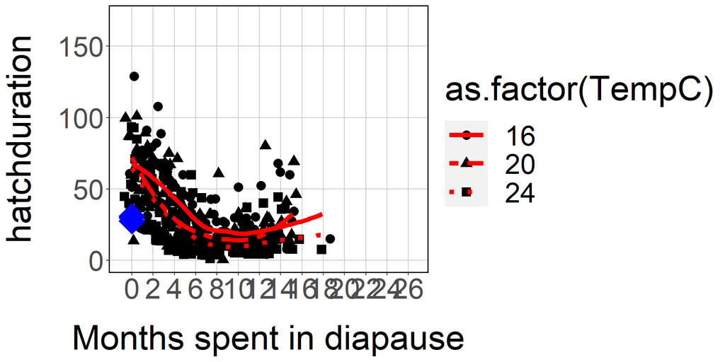

```r
treylevelplot(hatchduration) + NDpoint
```

### 3.5.2. Hatching duration stat

The general response of the hatching duration was affected by the the different time length spent in diapause and the different incubation temperatures.

```r
gamhd <- mgcv::gam(hatchduration ~ s(DiapMonths) + TempCf -1,
                   data = hatchtableNoND)

anova(gamhd)
```

```
##
## Family: gaussian
## Link function: identity
##
## Formula:
## hatchduration ~ s(DiapMonths) + TempCf - 1
##
## Parametric Terms:
##        df     F p-value
## TempCf  3 534.3  <2e-16
##
## Approximate significance of smooth terms:
##                 edf Ref.df     F p-value
## s(DiapMonths) 6.658  7.811 64.17  <2e-16
```

```r
# plot(gamhd)
# mgcv::gam.check(gamhd)

multgamhd <- glht(gamhd, linfct =c('TempCf16 - TempCf20 == 0',
                                   'TempCf16 - TempCf24 == 0',
                                   'TempCf20 - TempCf24 == 0'))
summary(multgamhd)
```

```
##
##   Simultaneous Tests for General Linear Hypotheses
##
## Fit: mgcv::gam(formula = hatchduration ~ s(DiapMonths) + TempCf -
##     1, data = hatchtableNoND)
##
## Linear Hypotheses:
##                          Estimate Std. Error z value Pr(>|z|)
## TempCf16 - TempCf20 == 0    6.739      1.829   3.684   <0.001 ***
## TempCf16 - TempCf24 == 0   11.613      1.828   6.352   <0.001 ***
## TempCf20 - TempCf24 == 0    4.874      1.781   2.736   0.0171 *
## ---
## Signif. codes:  0 '***' 0.001 '**' 0.01 '*' 0.05 '.' 0.1 ' ' 1
## (Adjusted p values reported -- single-step method)
```

```r
confint(multgamhd)$confint
```

```
##                      Estimate       lwr       upr
## TempCf16 - TempCf20  6.739106 2.4539712 11.024240
## TempCf16 - TempCf24 11.612653 7.3294569 15.895850
## TempCf20 - TempCf24  4.873548 0.7007448  9.046351
## attr(,"conf.level")
## [1] 0.95
## attr(,"calpha")
## [1] 2.342716
```

The pairwise comparisons of the different length CSE categories within the corresponding incubation temperature (not between them!) for hatching duration. 1. F statistics and compact letter display format between the categories. 2. Estimate, Std. Error, t-values and p-values above for all categories comparisons.

First, for the 24C incubated CSE eggs

```r
hatchduration24cld <- ModelDiap("hatchduration", 24)
```

```
## F statistics
##     value     numdf     dendf
##  28.78743   7.00000 140.00000
## All pairwise comparisons, with compact letter display
##           0 0.5 to 1.5m     2 to 4m     5 to 7m    8 to 10m   11 to 13m
##         "c"         "c"         "a"         "b"         "b"         "b"
##   14 to 16m 17m or more
##        "ab"        "ab"
##
##   Simultaneous Tests for General Linear Hypotheses
##
## Multiple Comparisons of Means: Tukey Contrasts
##
##
## Fit: lm(formula = formula0, data = df)
##
## Linear Hypotheses:
##                                Estimate Std. Error t value Pr(>|t|)
## 0.5 to 1.5m - 0 == 0           -16.0000     6.9393  -2.306  0.26469
## 2 to 4m - 0 == 0               -32.1394     6.4489  -4.984  < 0.001 ***
## 5 to 7m - 0 == 0               -52.2303     6.4489  -8.099  < 0.001 ***
## 8 to 10m - 0 == 0              -55.9857     6.5242  -8.581  < 0.001 ***
## 11 to 13m - 0 == 0             -56.3600     6.5832  -8.561  < 0.001 ***
## 14 to 16m - 0 == 0             -46.3250     7.6608  -6.047  < 0.001 ***
## 17m or more - 0 == 0           -59.2000    14.7205  -4.022  0.00186 **
## 2 to 4m - 0.5 to 1.5m == 0     -16.1394     4.1846  -3.857  0.00339 **
## 5 to 7m - 0.5 to 1.5m == 0     -36.2303     4.1846  -8.658  < 0.001 ***
## 8 to 10m - 0.5 to 1.5m == 0    -39.9857     4.2997  -9.300  < 0.001 ***
## 11 to 13m - 0.5 to 1.5m == 0   -40.3600     4.3888  -9.196  < 0.001 ***
## 14 to 16m - 0.5 to 1.5m == 0   -30.3250     5.8831  -5.155  < 0.001 ***
## 17m or more - 0.5 to 1.5m == 0 -43.2000    13.8787  -3.113  0.03764 *
## 5 to 7m - 2 to 4m == 0         -20.0909     3.3082  -6.073  < 0.001 ***
## 8 to 10m - 2 to 4m == 0        -23.8463     3.4527  -6.907  < 0.001 ***
## 11 to 13m - 2 to 4m == 0       -24.2206     3.5630  -6.798  < 0.001 ***
## 14 to 16m - 2 to 4m == 0       -14.1856     5.2957  -2.679  0.11816
## 17m or more - 2 to 4m == 0     -27.0606    13.6400  -1.984  0.45676
## 8 to 10m - 5 to 7m == 0         -3.7554     3.4527  -1.088  0.95021
## 11 to 13m - 5 to 7m == 0        -4.1297     3.5630  -1.159  0.93107
## 14 to 16m - 5 to 7m == 0         5.9053     5.2957   1.115  0.94336
## 17m or more - 5 to 7m == 0      -6.9697    13.6400  -0.511  0.99948
## 11 to 13m - 8 to 10m == 0       -0.3743     3.6976  -0.101  1.00000
## 14 to 16m - 8 to 10m == 0        9.6607     5.3872   1.793  0.58769
## 17m or more - 8 to 10m == 0     -3.2143    13.6758  -0.235  1.00000
## 14 to 16m - 11 to 13m == 0      10.0350     5.4585   1.838  0.55685
## 17m or more - 11 to 13m == 0    -2.8400    13.7041  -0.207  1.00000
## 17m or more - 14 to 16m == 0   -12.8750    14.2531  -0.903  0.98207
## ---
## Signif. codes:  0 '***' 0.001 '**' 0.01 '*' 0.05 '.' 0.1 ' ' 1
## (Adjusted p values reported -- single-step method)
```

Second, for the lowest, 16C incubated CSE eggs

```r
hatchduration16cld <-ModelDiap("hatchduration", 16)
```

```
## F statistics
##     value     numdf     dendf
##  21.95594   7.00000 125.00000
## All pairwise comparisons, with compact letter display
##           0 0.5 to 1.5m     2 to 4m     5 to 7m    8 to 10m   11 to 13m
##         "a"         "a"         "a"         "b"         "b"         "b"
##   14 to 16m 17m or more
##         "b"        "ab"
##
##   Simultaneous Tests for General Linear Hypotheses
##
## Multiple Comparisons of Means: Tukey Contrasts
##
##
## Fit: lm(formula = formula0, data = df)
##
## Linear Hypotheses:
##                                Estimate Std. Error t value Pr(>|t|)
## 0.5 to 1.5m - 0 == 0             -6.095      7.952  -0.767   0.9933
## 2 to 4m - 0 == 0                 -8.481      7.355  -1.153   0.9338
## 5 to 7m - 0 == 0                -38.797      7.471  -5.193   <0.001 ***
## 8 to 10m - 0 == 0               -43.505      7.268  -5.986   <0.001 ***
## 11 to 13m - 0 == 0              -47.580      7.471  -6.369   <0.001 ***
## 14 to 16m - 0 == 0              -28.667      8.801  -3.257   0.0255 *
## 17m or more - 0 == 0            -49.667     17.602  -2.822   0.0848 .
## 2 to 4m - 0.5 to 1.5m == 0       -2.386      5.367  -0.445   0.9998
## 5 to 7m - 0.5 to 1.5m == 0      -32.702      5.524  -5.920   <0.001 ***
## 8 to 10m - 0.5 to 1.5m == 0     -37.410      5.248  -7.129   <0.001 ***
## 11 to 13m - 0.5 to 1.5m == 0    -41.484      5.524  -7.510   <0.001 ***
## 14 to 16m - 0.5 to 1.5m == 0    -22.571      7.223  -3.125   0.0378 *
## 17m or more - 0.5 to 1.5m == 0  -43.571     16.869  -2.583   0.1514
## 5 to 7m - 2 to 4m == 0          -30.316      4.624  -6.556   <0.001 ***
## 8 to 10m - 2 to 4m == 0         -35.024      4.290  -8.164   <0.001 ***
## 11 to 13m - 2 to 4m == 0        -39.098      4.624  -8.455   <0.001 ***
## 14 to 16m - 2 to 4m == 0        -20.185      6.560  -3.077   0.0432 *
## 17m or more - 2 to 4m == 0      -41.185     16.596  -2.482   0.1887
## 8 to 10m - 5 to 7m == 0          -4.708      4.485  -1.050   0.9594
## 11 to 13m - 5 to 7m == 0         -8.783      4.806  -1.828   0.5681
## 14 to 16m - 5 to 7m == 0         10.130      6.689   1.514   0.7734
## 17m or more - 5 to 7m == 0      -10.870     16.647  -0.653   0.9975
## 11 to 13m - 8 to 10m == 0        -4.074      4.485  -0.908   0.9818
## 14 to 16m - 8 to 10m == 0        14.839      6.463   2.296   0.2741
## 17m or more - 8 to 10m == 0      -6.161     16.557  -0.372   0.9999
## 14 to 16m - 11 to 13m == 0       18.913      6.689   2.827   0.0841 .
## 17m or more - 11 to 13m == 0     -2.087     16.647  -0.125   1.0000
## 17m or more - 14 to 16m == 0    -21.000     17.285  -1.215   0.9143
## ---
## Signif. codes:  0 '***' 0.001 '**' 0.01 '*' 0.05 '.' 0.1 ' ' 1
## (Adjusted p values reported -- single-step method)
```

Third, for the 20C incubated CSE eggs

```r
hatchduration20cld <-ModelDiap("hatchduration", 20)
```

```
## F statistics
##     value     numdf     dendf
##  25.52096   6.00000 140.00000
## All pairwise comparisons, with compact letter display
##           0 0.5 to 1.5m     2 to 4m     5 to 7m    8 to 10m   11 to 13m
##         "c"         "c"         "b"         "a"         "a"         "a"
##   14 to 16m
##        "ab"
##
##   Simultaneous Tests for General Linear Hypotheses
##
## Multiple Comparisons of Means: Tukey Contrasts
##
##
## Fit: lm(formula = formula0, data = df)
##
## Linear Hypotheses:
##                              Estimate Std. Error t value Pr(>|t|)
## 0.5 to 1.5m - 0 == 0          -15.193      7.380  -2.059  0.36854
## 2 to 4m - 0 == 0              -35.741      6.857  -5.212  < 0.001 ***
## 5 to 7m - 0 == 0              -53.044      6.997  -7.581  < 0.001 ***
## 8 to 10m - 0 == 0             -57.394      6.920  -8.294  < 0.001 ***
## 11 to 13m - 0 == 0            -56.286      6.944  -8.105  < 0.001 ***
## 14 to 16m - 0 == 0            -41.804      8.505  -4.915  < 0.001 ***
## 2 to 4m - 0.5 to 1.5m == 0    -20.548      4.932  -4.166  < 0.001 ***
## 5 to 7m - 0.5 to 1.5m == 0    -37.851      5.126  -7.385  < 0.001 ***
## 8 to 10m - 0.5 to 1.5m == 0   -42.201      5.020  -8.407  < 0.001 ***
## 11 to 13m - 0.5 to 1.5m == 0  -41.092      5.053  -8.133  < 0.001 ***
## 14 to 16m - 0.5 to 1.5m == 0  -26.610      7.046  -3.777  0.00404 **
## 5 to 7m - 2 to 4m == 0        -17.303      4.339  -3.988  0.00204 **
## 8 to 10m - 2 to 4m == 0       -21.653      4.213  -5.139  < 0.001 ***
## 11 to 13m - 2 to 4m == 0      -20.545      4.252  -4.831  < 0.001 ***
## 14 to 16m - 2 to 4m == 0       -6.062      6.496  -0.933  0.96414
## 8 to 10m - 5 to 7m == 0        -4.350      4.438  -0.980  0.95461
## 11 to 13m - 5 to 7m == 0       -3.242      4.476  -0.724  0.99018
## 14 to 16m - 5 to 7m == 0       11.240      6.644   1.692  0.60864
## 11 to 13m - 8 to 10m == 0       1.108      4.354   0.255  0.99997
## 14 to 16m - 8 to 10m == 0      15.591      6.563   2.376  0.20601
## 14 to 16m - 11 to 13m == 0     14.482      6.588   2.198  0.29000
## ---
## Signif. codes:  0 '***' 0.001 '**' 0.01 '*' 0.05 '.' 0.1 ' ' 1
## (Adjusted p values reported -- single-step method)
```

The significance letters has been saved to a list (hatchdurationcld) to later add to the big summary table. See section 4.

```r
hatchdurationcld <-
  do.call(rbind, list(hatchduration16cld, hatchduration20cld, hatchduration24cld))
```

Comparisons of the hatching duration of the ND, 8-10 months CSE and 0 months spent in diapause CSE eggs at 24C. To change 16 or 20 C please go back to the line 330 at the part of hatchtableforND creation, and change it for an other one and run the model with the code again.

```r
NDcomp("hatchduration")
```

```
##       ND        0 8 to 10m
##      "b"      "c"      "a"
##
##   Simultaneous Tests for General Linear Hypotheses
##
## Multiple Comparisons of Means: Tukey Contrasts
##
##
## Fit: lm(formula = formula0, data = hatchtableforND)
##
## Linear Hypotheses:
##                    Estimate Std. Error t value Pr(>|t|)
## 0 - ND == 0          39.771      7.870   5.054   <0.001 ***
## 8 to 10m - ND == 0  -16.214      5.679  -2.855   0.0181 *
## 8 to 10m - 0 == 0   -55.986      6.525  -8.580   <0.001 ***
## ---
## Signif. codes:  0 '***' 0.001 '**' 0.01 '*' 0.05 '.' 0.1 ' ' 1
## (Adjusted p values reported -- single-step method)
```

## 3.6. Hatching percentage

*please note that at the data assessment phase the hatching percentage was coded as "hatching ratio". We kept that phrase, besides that later it has been changed

### 3.6.1. Hatch percentage visualization

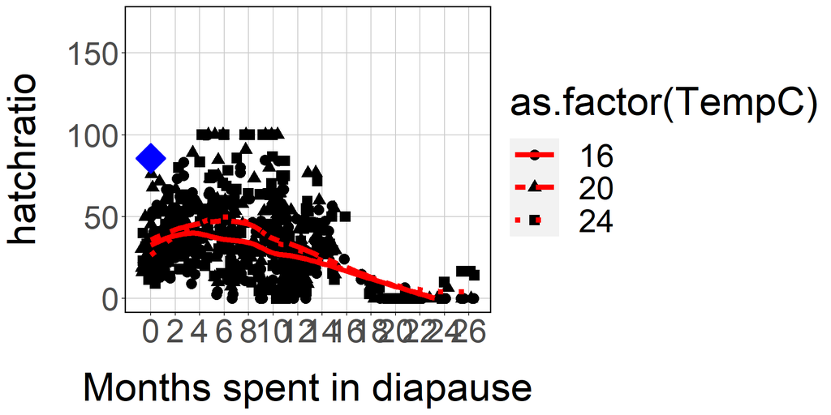

```r
treylevelplot(hatchratio) + NDpoint
```

### 3.6.2. Hatch percentage statistics

The general response of the hatching percentages was affected by the the different time length spent in diapause and the different incubation temperatures.

```r
gamhr <- mgcv::gam(hatchratio ~ s(DiapMonths) + TempCf -1,
                   data = hatchtableNoND)

anova(gamhr)
```

```
##
## Family: gaussian
## Link function: identity
##
## Formula:
## hatchratio ~ s(DiapMonths) + TempCf - 1
##
## Parametric Terms:
##        df     F p-value
## TempCf  3 611.8  <2e-16
##
## Approximate significance of smooth terms:
##                 edf Ref.df     F p-value
## s(DiapMonths) 8.743  8.980 31.11  <2e-16
```

```r
# plot(gamhr)
# mgcv::gam.check(gamhr)

multgamhr <- glht(gamhr, linfct =c('TempCf16 - TempCf20 == 0',
                                   'TempCf16 - TempCf24 == 0',
                                   'TempCf20 - TempCf24 == 0'))
summary(multgamhr)
```

```
##
##   Simultaneous Tests for General Linear Hypotheses
##
## Fit: mgcv::gam(formula = hatchratio ~ s(DiapMonths) + TempCf - 1,
##     data = hatchtableNoND)
##
## Linear Hypotheses:
##                          Estimate Std. Error z value Pr(>|z|)
## TempCf16 - TempCf20 == 0   -5.894      1.887  -3.124   0.0051 **
## TempCf16 - TempCf24 == 0   -4.551      1.887  -2.412   0.0420 *
## TempCf20 - TempCf24 == 0    1.343      1.887   0.712   0.7564
## ---
## Signif. codes:  0 '***' 0.001 '**' 0.01 '*' 0.05 '.' 0.1 ' ' 1
## (Adjusted p values reported -- single-step method)
```

```r
confint(multgamhr)$confint
```

```
##                      Estimate        lwr        upr
## TempCf16 - TempCf20 -5.894001 -10.314556 -1.4734460
## TempCf16 - TempCf24 -4.550754  -8.971308 -0.1301988
## TempCf20 - TempCf24  1.343247  -3.077308  5.7638020
## attr(,"conf.level")
## [1] 0.95
## attr(,"calpha")
## [1] 2.343036
```

The pairwise comparisons of the different length CSE categories within the corresponding incubation temperature (not between them!) for hatching percentages. 1. F statistics and compact letter display format between the categories. 2. Estimate, Std. Error, t-values and p-values above for all categories comparisons.

First, for the 24C incubated CSE eggs

```r
hatchratio24cld <- ModelDiap("hatchratio", 24)
```

```
## F statistics
##     value     numdf     dendf
##  17.15395   7.00000 216.00000
## All pairwise comparisons, with compact letter display
##           0 0.5 to 1.5m     2 to 4m     5 to 7m    8 to 10m   11 to 13m
##        "bc"        "bd"       "cde"         "e"        "de"         "b"
##   14 to 16m 17m or more
##        "be"         "a"
##
##   Simultaneous Tests for General Linear Hypotheses
##
## Multiple Comparisons of Means: Tukey Contrasts
##
##
## Fit: lm(formula = formula0, data = df)
##
## Linear Hypotheses:
##                                Estimate Std. Error t value Pr(>|t|)
## 0.5 to 1.5m - 0 == 0              4.538      7.223   0.628  0.99830
## 2 to 4m - 0 == 0                 14.281      6.594   2.166  0.36114
## 5 to 7m - 0 == 0                 21.713      6.594   3.293  0.02385 *
## 8 to 10m - 0 == 0                19.926      6.511   3.060  0.04638 *
## 11 to 13m - 0 == 0               -4.918      6.385  -0.770  0.99392
## 14 to 16m - 0 == 0                6.114      9.029   0.677  0.99727
## 17m or more - 0 == 0            -24.072      6.994  -3.442  0.01440 *
## 2 to 4m - 0.5 to 1.5m == 0        9.743      5.517   1.766  0.62818
## 5 to 7m - 0.5 to 1.5m == 0       17.175      5.517   3.113  0.04009 *
## 8 to 10m - 0.5 to 1.5m == 0      15.387      5.418   2.840  0.08450 .
## 11 to 13m - 0.5 to 1.5m == 0     -9.456      5.265  -1.796  0.60790
## 14 to 16m - 0.5 to 1.5m == 0      1.576      8.275   0.190  1.00000
## 17m or more - 0.5 to 1.5m == 0  -28.610      5.989  -4.777  < 0.001 ***
## 5 to 7m - 2 to 4m == 0            7.432      4.663   1.594  0.74102
## 8 to 10m - 2 to 4m == 0           5.644      4.545   1.242  0.91259
## 11 to 13m - 2 to 4m == 0        -19.199      4.362  -4.402  < 0.001 ***
## 14 to 16m - 2 to 4m == 0         -8.167      7.732  -1.056  0.96209
## 17m or more - 2 to 4m == 0      -38.353      5.213  -7.357  < 0.001 ***
## 8 to 10m - 5 to 7m == 0          -1.788      4.545  -0.393  0.99992
## 11 to 13m - 5 to 7m == 0        -26.631      4.362  -6.106  < 0.001 ***
## 14 to 16m - 5 to 7m == 0        -15.599      7.732  -2.017  0.45645
## 17m or more - 5 to 7m == 0      -45.785      5.213  -8.783  < 0.001 ***
## 11 to 13m - 8 to 10m == 0       -24.843      4.235  -5.866  < 0.001 ***
## 14 to 16m - 8 to 10m == 0       -13.811      7.662  -1.803  0.60324
## 17m or more - 8 to 10m == 0     -43.998      5.108  -8.614  < 0.001 ***
## 14 to 16m - 11 to 13m == 0       11.032      7.554   1.460  0.81731
## 17m or more - 11 to 13m == 0    -19.154      4.946  -3.873  0.00334 **
## 17m or more - 14 to 16m == 0    -30.186      8.076  -3.738  0.00529 **
## ---
## Signif. codes:  0 '***' 0.001 '**' 0.01 '*' 0.05 '.' 0.1 ' ' 1
## (Adjusted p values reported -- single-step method)
```

Second, for the lowest, 16C incubated CSE eggs

```r
hatchratio16cld <-ModelDiap("hatchratio", 16)
```

```
## F statistics
##     value     numdf     dendf
##  14.07723   7.00000 216.00000
## All pairwise comparisons, with compact letter display
##           0 0.5 to 1.5m     2 to 4m     5 to 7m    8 to 10m   11 to 13m
##        "bc"        "bc"         "c"         "c"         "c"         "b"
##   14 to 16m 17m or more
##        "bc"         "a"
##
##   Simultaneous Tests for General Linear Hypotheses
##
## Multiple Comparisons of Means: Tukey Contrasts
##
##
## Fit: lm(formula = formula0, data = df)
##
## Linear Hypotheses:
##                                Estimate Std. Error t value Pr(>|t|)
## 0.5 to 1.5m - 0 == 0            -2.9506     6.8055  -0.434   0.9999
## 2 to 4m - 0 == 0                 5.7339     6.2126   0.923   0.9822
## 5 to 7m - 0 == 0                 2.7319     6.2126   0.440   0.9998
## 8 to 10m - 0 == 0                4.0374     6.1344   0.658   0.9977
## 11 to 13m - 0 == 0             -15.4210     6.0153  -2.564   0.1650
## 14 to 16m - 0 == 0               3.4271     8.5069   0.403   0.9999
## 17m or more - 0 == 0           -32.7647     6.5894  -4.972   <0.001 ***
## 2 to 4m - 0.5 to 1.5m == 0       8.6845     5.1978   1.671   0.6920
## 5 to 7m - 0.5 to 1.5m == 0       5.6825     5.1978   1.093   0.9544
## 8 to 10m - 0.5 to 1.5m == 0      6.9880     5.1041   1.369   0.8619
## 11 to 13m - 0.5 to 1.5m == 0   -12.4704     4.9603  -2.514   0.1843
## 14 to 16m - 0.5 to 1.5m == 0     6.3777     7.7967   0.818   0.9912
## 17m or more - 0.5 to 1.5m == 0 -29.8141     5.6428  -5.284   <0.001 ***
## 5 to 7m - 2 to 4m == 0          -3.0020     4.3929  -0.683   0.9971
## 8 to 10m - 2 to 4m == 0         -1.6965     4.2817  -0.396   0.9999
## 11 to 13m - 2 to 4m == 0       -21.1549     4.1092  -5.148   <0.001 ***
## 14 to 16m - 2 to 4m == 0        -2.3068     7.2849  -0.317   1.0000
## 17m or more - 2 to 4m == 0     -38.4986     4.9115  -7.839   <0.001 ***
## 8 to 10m - 5 to 7m == 0          1.3054     4.2817   0.305   1.0000
## 11 to 13m - 5 to 7m == 0       -18.1529     4.1092  -4.418   <0.001 ***
## 14 to 16m - 5 to 7m == 0         0.6952     7.2849   0.095   1.0000
## 17m or more - 5 to 7m == 0     -35.4966     4.9115  -7.227   <0.001 ***
## 11 to 13m - 8 to 10m == 0      -19.4584     3.9901  -4.877   <0.001 ***
## 14 to 16m - 8 to 10m == 0       -0.6103     7.2183  -0.085   1.0000
## 17m or more - 8 to 10m == 0    -36.8021     4.8122  -7.648   <0.001 ***
## 14 to 16m - 11 to 13m == 0      18.8481     7.1174   2.648   0.1361
## 17m or more - 11 to 13m == 0   -17.3437     4.6594  -3.722   0.0056 **
## 17m or more - 14 to 16m == 0   -36.1918     7.6088  -4.757   <0.001 ***
## ---
## Signif. codes:  0 '***' 0.001 '**' 0.01 '*' 0.05 '.' 0.1 ' ' 1
## (Adjusted p values reported -- single-step method)
```

Third, for the 20C incubated CSE eggs

```r
hatchratio20cld <-ModelDiap("hatchratio", 20)
```

```
## F statistics
##     value     numdf     dendf
##  16.37668   7.00000 216.00000
## All pairwise comparisons, with compact letter display
##           0 0.5 to 1.5m     2 to 4m     5 to 7m    8 to 10m   11 to 13m
##        "bc"        "bc"         "c"         "c"         "c"         "b"
##   14 to 16m 17m or more
##        "bc"         "a"
##
##   Simultaneous Tests for General Linear Hypotheses
##
## Multiple Comparisons of Means: Tukey Contrasts
##
##
## Fit: lm(formula = formula0, data = df)
##
## Linear Hypotheses:
##                                Estimate Std. Error t value Pr(>|t|)
## 0.5 to 1.5m - 0 == 0              5.395      7.355   0.734  0.99550
## 2 to 4m - 0 == 0                  8.861      6.714   1.320  0.88323
## 5 to 7m - 0 == 0                 12.635      6.714   1.882  0.54859
## 8 to 10m - 0 == 0                14.699      6.629   2.217  0.33124
## 11 to 13m - 0 == 0               -8.476      6.501  -1.304  0.88957
## 14 to 16m - 0 == 0               -2.351      9.193  -0.256  1.00000
## 17m or more - 0 == 0            -32.608      7.121  -4.579  < 0.001 ***
## 2 to 4m - 0.5 to 1.5m == 0        3.466      5.617   0.617  0.99849
## 5 to 7m - 0.5 to 1.5m == 0        7.240      5.617   1.289  0.89553
## 8 to 10m - 0.5 to 1.5m == 0       9.304      5.516   1.687  0.68166
## 11 to 13m - 0.5 to 1.5m == 0    -13.871      5.361  -2.588  0.15665
## 14 to 16m - 0.5 to 1.5m == 0     -7.746      8.426  -0.919  0.98256
## 17m or more - 0.5 to 1.5m == 0  -38.003      6.098  -6.232  < 0.001 ***
## 5 to 7m - 2 to 4m == 0            3.773      4.747   0.795  0.99264
## 8 to 10m - 2 to 4m == 0           5.838      4.627   1.262  0.90565
## 11 to 13m - 2 to 4m == 0        -17.337      4.441  -3.904  0.00281 **
## 14 to 16m - 2 to 4m == 0        -11.212      7.873  -1.424  0.83574
## 17m or more - 2 to 4m == 0      -41.469      5.308  -7.813  < 0.001 ***
## 8 to 10m - 5 to 7m == 0           2.065      4.627   0.446  0.99982
## 11 to 13m - 5 to 7m == 0        -21.111      4.441  -4.754  < 0.001 ***
## 14 to 16m - 5 to 7m == 0        -14.986      7.873  -1.904  0.53362
## 17m or more - 5 to 7m == 0      -45.243      5.308  -8.524  < 0.001 ***
## 11 to 13m - 8 to 10m == 0       -23.176      4.312  -5.375  < 0.001 ***
## 14 to 16m - 8 to 10m == 0       -17.050      7.801  -2.186  0.34917
## 17m or more - 8 to 10m == 0     -47.308      5.200  -9.097  < 0.001 ***
## 14 to 16m - 11 to 13m == 0        6.125      7.692   0.796  0.99255
## 17m or more - 11 to 13m == 0    -24.132      5.035  -4.792  < 0.001 ***
## 17m or more - 14 to 16m == 0    -30.257      8.223  -3.680  0.00630 **
## ---
## Signif. codes:  0 '***' 0.001 '**' 0.01 '*' 0.05 '.' 0.1 ' ' 1
## (Adjusted p values reported -- single-step method)
```

The significance letters has been saved to a list (hatchratiocld) to later add to the big summary table. See section 4.

```r
hatchratiocld <-
  do.call(rbind, list(hatchratio16cld, hatchratio20cld, hatchratio24cld))
```

Comparisons of the hatching percentages of the ND, 8-10 months CSE and 0 months spent in diapause CSE eggs at 24C. To change 16 or 20 C please go back to the line 330 at the part of hatchtableforND creation, and change it for an other one and run the model with the code again.

```r
NDcomp("hatchratio")
```

```
##       ND        0 8 to 10m
##      "b"      "a"      "a"
##
##   Simultaneous Tests for General Linear Hypotheses
##
## Multiple Comparisons of Means: Tukey Contrasts
##
##
## Fit: lm(formula = formula0, data = hatchtableforND)
##
## Linear Hypotheses:
##                    Estimate Std. Error t value Pr(>|t|)
## 0 - ND == 0         -58.260     11.623  -5.012  < 1e-04 ***
## 8 to 10m - ND == 0  -38.335      9.862  -3.887  0.00076 ***
## 8 to 10m - 0 == 0    19.926      8.381   2.377  0.05198 .
## ---
## Signif. codes:  0 '***' 0.001 '**' 0.01 '*' 0.05 '.' 0.1 ' ' 1
## (Adjusted p values reported -- single-step method)
```

## 3.7. Overwinter survival

### 3.7.1. Data visualization of the overwintering survival

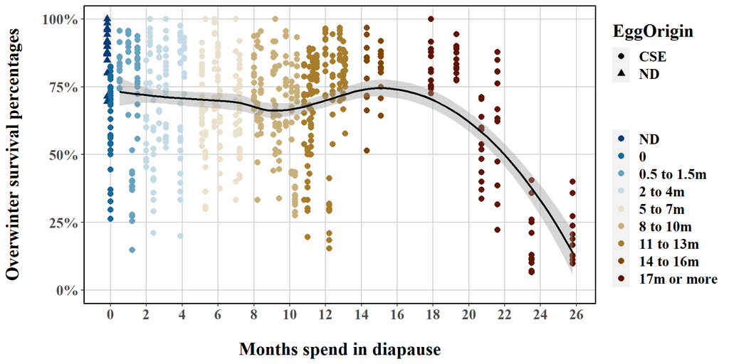

```r
#adding Overwintsurvival to traytable
traytable$OverwintSurv <-
  traytable$EggsAlive / (traytable$EggsAlive + traytable$EggsDead)

#small summary table created: survdata (pls note that the catergories created under the name of Diapmonths are differ from MonCatBreaks which used in the other part of the anlysis)
survdata <- summarise(group_by(traytable, DiapMonCat, EggOrigin),
                      OverwintSurvAvg = mean(OverwintSurv),
                      OverwintSurvSD = sd(OverwintSurv))
survdata$DiapMonths <- c(0,0,1,3,6,9,12,15,21.5)

#data visulasation (plotOverWinter)
pOW <- ggplot(traytable,
            aes(DiapMonths - (EggOrigin == "ND") * .2, OverwintSurv,
                shape = EggOrigin)) +
  geom_point(aes(col = DiapMonCat), size = 2.5) +
  scale_x_continuous(breaks = scalebreakx) +
  scale_y_continuous(labels = scales::percent_format(),
                     breaks = c(0, 0.25, 0.50, 0.75 , 1.0)) +
  scale_color_manual(values = scico(9, begin = 0.1, palette = "vik")) +
  theme(
        text = element_text(size = 18, face = "bold", family = "serif"),
        panel.background = element_rect(fill = NA),
        panel.grid.major = element_line(colour = "grey80"),
        axis.title.y = element_text(margin = margin(r = +20)),
        axis.title.x = element_text(margin = margin(t = +20)),
        panel.border = element_rect(color = "black", fill = NA, size = 1)) +
   labs(x ="Months spend in diapause",
        y = "Overwinter survival percentages",
        color = "") +
  expand_limits(y = 0)

#two smoothed lines adding for above and below 16 months categories
pOW + geom_smooth(data = filter(traytable, DiapMonths > 0), col = "black")
```

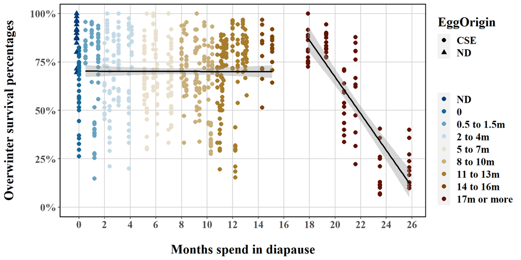

```r
pOW + geom_smooth(data = filter(traytable, DiapMonths > 16),
                method = "lm", col = "black") +
  geom_smooth(data = filter(traytable, DiapMonths > 0 & DiapMonths < 16 ),
              method = "lm", col = "black")
```

### 3.7.2. Overwintering survival statistics

Proving that below 16 months the dipause length has no effect on the overwintering survival (see trend line in the above section) while above 16 months there is a decreasing trend (also, see trend line in the previous section). First, separating the data and fit two linear regressions.

```
modshort <- lm(OverwintSurv ~ DiapMonths,
               data = traytable[traytable$DiapMonths < 16,])
summary(modshort)


modlong<- lm(OverwintSurv ~ DiapMonths,
               data = traytable[traytable$DiapMonths > 16,])
summary(modlong)
```

More detailed, pairwise comparisons of the different categories if they differ or not from the longest (17m or more) dipause spent eggs

```r
dfOver <- traytable[traytable$DiapMonths != 0,] #ND data is not involved
modhs <- lm(OverwintSurv ~ DiapMonCat, dfOver)
multmodhs <- glht(modhs, linfct = mcp(DiapMonCat = "Tukey"))
cld(multmodhs)
```

```
## 0.5 to 1.5m     2 to 4m     5 to 7m    8 to 10m   11 to 13m   14 to 16m
##         "b"         "b"         "b"         "b"         "b"         "b"
## 17m or more
##         "a"
```

```r
summary(multmodhs)
```

```
##
##   Simultaneous Tests for General Linear Hypotheses
##
## Multiple Comparisons of Means: Tukey Contrasts
##
##
## Fit: lm(formula = OverwintSurv ~ DiapMonCat, data = dfOver)
##
## Linear Hypotheses:
##                                 Estimate Std. Error t value Pr(>|t|)
## 2 to 4m - 0.5 to 1.5m == 0     -0.023811   0.032396  -0.735   0.9897
## 5 to 7m - 0.5 to 1.5m == 0     -0.057008   0.032396  -1.760   0.5625
## 8 to 10m - 0.5 to 1.5m == 0    -0.059724   0.031812  -1.877   0.4829
## 11 to 13m - 0.5 to 1.5m == 0   -0.036686   0.030916  -1.187   0.8937
## 14 to 16m - 0.5 to 1.5m == 0    0.063305   0.048594   1.303   0.8434
## 17m or more - 0.5 to 1.5m == 0 -0.202824   0.035170  -5.767   <0.001 ***
## 5 to 7m - 2 to 4m == 0         -0.033198   0.027380  -1.212   0.8835
## 8 to 10m - 2 to 4m == 0        -0.035913   0.026686  -1.346   0.8218
## 11 to 13m - 2 to 4m == 0       -0.012875   0.025611  -0.503   0.9987
## 14 to 16m - 2 to 4m == 0        0.087115   0.045404   1.919   0.4551
## 17m or more - 2 to 4m == 0     -0.179013   0.030611  -5.848   <0.001 ***
## 8 to 10m - 5 to 7m == 0        -0.002715   0.026686  -0.102   1.0000
## 11 to 13m - 5 to 7m == 0        0.020322   0.025611   0.793   0.9846
## 14 to 16m - 5 to 7m == 0        0.120313   0.045404   2.650   0.1073
## 17m or more - 5 to 7m == 0     -0.145816   0.030611  -4.763   <0.001 ***
## 11 to 13m - 8 to 10m == 0       0.023038   0.024869   0.926   0.9663
## 14 to 16m - 8 to 10m == 0       0.123028   0.044990   2.735   0.0863 .
## 17m or more - 8 to 10m == 0    -0.143100   0.029993  -4.771   <0.001 ***
## 14 to 16m - 11 to 13m == 0      0.099991   0.044360   2.254   0.2571
## 17m or more - 11 to 13m == 0   -0.166138   0.029041  -5.721   <0.001 ***
## 17m or more - 14 to 16m == 0   -0.266128   0.047423  -5.612   <0.001 ***
## ---
## Signif. codes:  0 '***' 0.001 '**' 0.01 '*' 0.05 '.' 0.1 ' ' 1
## (Adjusted p values reported -- single-step method)
```

```r
confint(multmodhs)$confint
```

```
##                               Estimate          lwr         upr
## 2 to 4m - 0.5 to 1.5m     -0.023810715 -0.118931812  0.07131038
## 5 to 7m - 0.5 to 1.5m     -0.057008234 -0.152129331  0.03811286
## 8 to 10m - 0.5 to 1.5m    -0.059723572 -0.153130635  0.03368349
## 11 to 13m - 0.5 to 1.5m   -0.036686053 -0.127461401  0.05408930
## 14 to 16m - 0.5 to 1.5m    0.063304509 -0.079377136  0.20598615
## 17m or more - 0.5 to 1.5m -0.202823864 -0.306089258 -0.09955847
## 5 to 7m - 2 to 4m         -0.033197519 -0.113589519  0.04719448
## 8 to 10m - 2 to 4m        -0.035912857 -0.114269286  0.04244357
## 11 to 13m - 2 to 4m       -0.012875338 -0.088075168  0.06232449
## 14 to 16m - 2 to 4m        0.087115224 -0.046199826  0.22043027
## 17m or more - 2 to 4m     -0.179013149 -0.268894137 -0.08913216
## 8 to 10m - 5 to 7m        -0.002715338 -0.081071767  0.07564109
## 11 to 13m - 5 to 7m        0.020322182 -0.054877648  0.09552201
## 14 to 16m - 5 to 7m        0.120312744 -0.013002306  0.25362779
## 17m or more - 5 to 7m     -0.145815630 -0.235696618 -0.05593464
## 11 to 13m - 8 to 10m       0.023037520 -0.049982140  0.09605718
## 14 to 16m - 8 to 10m       0.123028082 -0.009069454  0.25512562
## 17m or more - 8 to 10m    -0.143100292 -0.231165315 -0.05503527
## 14 to 16m - 11 to 13m      0.099990562 -0.030259364  0.23024049
## 17m or more - 11 to 13m   -0.166137811 -0.251406404 -0.08086922
## 17m or more - 14 to 16m   -0.266128373 -0.405371402 -0.12688535
## attr(,"conf.level")
## [1] 0.95
## attr(,"calpha")
## [1] 2.936184
```

# 4. Main, summary table

## 4.1. Means and sds

Using all tray data (as replicates), taking all data within a category and incubation temperature and take the mean and sd. Hatchtablesum has been created for that.

```r
hatchtablesum <- summarise_at(group_by(hatchtable,
                                     TempC, DiapMonCat),
                            vars(starts_with("hatch")),
                            list(mean = mean, sd = sd), na.rm = TRUE)

Nhelper <- summarise(group_by(hatchtable, TempC, DiapMonCat),
                     nDish = n(),
                     nEgg = sum(EggsAlive, na.rm = TRUE),
                     eggPerDish = mean(EggsAlive, na.rm = TRUE))

hatchtablesum <- merge(hatchtablesum, Nhelper, sort = FALSE)

hatchtablesum[, -(1:2)] <- round(hatchtablesum[, -(1:2)])

hatchtablesum <-
  within(hatchtablesum,{
    Hatchratio <-
      paste(hatchratio_mean, hatchratio_sd, sep = " 戼㸱 ")
    Hatchduration <-
      paste(hatchduration_mean, hatchduration_sd, sep = " 戼㸱 ")
    Hatchend <-
      paste(hatchend_mean, hatchend_sd, sep = " 戼㸱 ")
    Hatchpeak <-
      paste(hatchpeak_mean, hatchpeak_sd, sep = " 戼㸱 ")
    Hatchstart <-
      paste(hatchstart_mean, hatchstart_sd, sep = " 戼㸱 ")
    })


hatchtablesum <- dplyr::select(hatchtablesum,
                        -starts_with("hatch", ignore.case = FALSE))

knitr::kable(hatchtablesum, align = "c") #knitting together
```

| TempC | DiapMonCat | nDish | nEgg | eggPerDish | Hatchstart | Hatchpeak | Hatchend | Hatchduration | Hatchratio |
| --- | --- | --- | --- | --- | --- | --- | --- | --- | --- |
| 16 | ND | 8 | 316 | 40 | 62 12 | 70 11 | 90 11 | 30 11 | 85 16 |
| 16 | 0 | 12 | 241 | 20 | 122 37 | 155 21 | 186 12 | 65 35 | 34 11 |
| 16 | 0.5 to 1.5m | 20 | 628 | 31 | 93 12 | 113 17 | 151 21 | 59 23 | 31 15 |
| 16 | 2 to 4m | 36 | 1154 | 32 | 70 10 | 84 19 | 125 19 | 56 18 | 40 18 |
| 16 | 5 to 7m | 36 | 1138 | 32 | 52 7 | 57 10 | 76 13 | 26 11 | 37 26 |
| 16 | 8 to 10m | 40 | 1693 | 42 | 46 3 | 50 5 | 66 10 | 21 10 | 38 24 |
| 16 | 11 to 13m | 48 | 1485 | 31 | 56 14 | 57 14 | 72 20 | 17 10 | 19 15 |
| 16 | 14 to 16m | 8 | 350 | 44 | 57 11 | 68 7 | 92 22 | 36 24 | 38 14 |
| 16 | 17m or more | 24 | 582 | 24 | 53 NA | 70 6 | 67 NA | 15 NA | 2 4 |
| 20 | ND | 8 | 412 | 52 | 24 2 | 27 3 | 54 16 | 31 17 | 86 16 |
| 20 | 0 | 12 | 248 | 21 | 60 19 | 93 26 | 131 16 | 72 31 | 34 22 |
| 20 | 0.5 to 1.5m | 20 | 641 | 32 | 36 9 | 61 21 | 92 23 | 57 18 | 40 12 |
| 20 | 2 to 4m | 36 | 1719 | 48 | 28 5 | 38 12 | 64 22 | 37 20 | 43 15 |
| 20 | 5 to 7m | 36 | 1186 | 33 | 27 3 | 32 5 | 46 9 | 19 9 | 47 25 |
| 20 | 8 to 10m | 40 | 1278 | 32 | 28 2 | 31 2 | 42 10 | 15 11 | 49 28 |
| 20 | 11 to 13m | 48 | 1595 | 33 | 27 3 | 30 5 | 42 16 | 16 15 | 26 19 |
| 20 | 14 to 16m | 8 | 792 | 99 | 28 1 | 33 1 | 58 20 | 31 20 | 32 11 |
| 20 | 17m or more | 24 | 571 | 24 | NaN NA | 37 5 | NaN NA | NaN NA | 2 4 |
| 24 | ND | 8 | 413 | 52 | 16 1 | 18 1 | 42 21 | 27 22 | 86 13 |
| 24 | 0 | 12 | 270 | 22 | 50 24 | 56 19 | 116 10 | 67 25 | 28 11 |
| 24 | 0.5 to 1.5m | 20 | 637 | 32 | 26 7 | 41 13 | 77 20 | 51 19 | 32 13 |
| 24 | 2 to 4m | 36 | 1735 | 48 | 20 1 | 25 6 | 54 15 | 35 16 | 42 18 |
| 24 | 5 to 7m | 36 | 1406 | 39 | 20 2 | 23 7 | 34 14 | 15 13 | 49 22 |
| 24 | 8 to 10m | 40 | 1558 | 39 | 19 2 | 22 6 | 29 7 | 11 7 | 48 30 |
| 24 | 11 to 13m | 48 | 1503 | 31 | 19 1 | 21 3 | 29 7 | 11 7 | 23 18 |
| 24 | 14 to 16m | 8 | 558 | 70 | 20 3 | 23 3 | 40 14 | 21 15 | 34 15 |
| 24 | 17m or more | 24 | 539 | 22 | 26 NA | 34 13 | 33 NA | 8 NA | 4 6 |

Please note that a, this table later on took out from here and altered and shaped in Excel (final format different in the article) b, the CV values later added in Excel, no code for that here! d, separator symbol could be not visible or wrong after running the code and saving the graph or knitting the document to html or pdf

## 4.2. Attach significance letters

Significance letters gathered to one table summary. Pls note that these letters added later manually to the main summary table in Excel.

```r
knitr::kable(Reduce(function(x, y) merge(x, y, sort = FALSE),
                    list(hatchstartcld,
                         hatchpeakcld,
                         hatchendcld,
                         hatchdurationcld,
                         hatchratiocld)),
             align = "c")
```

| TempC | DiapMonCat | hatchstartCLD | hatchpeakCLD | hatchendCLD | hatchdurationCLD | hatchratioCLD |
| --- | --- | --- | --- | --- | --- | --- |
| 16 | 0 | e | e | e | a | bc |
| 16 | 0.5 to 1.5m | d | d | d | a | bc |
| 16 | 2 to 4m | c | c | c | a | c |
| 16 | 5 to 7m | ab | ab | ab | b | c |
| 16 | 8 to 10m | a | a | a | b | c |
| 16 | 11 to 13m | b | ab | ab | b | b |
| 16 | 14 to 16m | abc | b | b | b | bc |
| 16 | 17m or more | abc | abc | ab | ab | a |
| 20 | 0 | c | c | d | c | bc |
| 20 | 0.5 to 1.5m | b | b | c | c | bc |
| 20 | 2 to 4m | a | a | b | b | c |
| 20 | 5 to 7m | a | a | a | a | c |
| 20 | 8 to 10m | a | a | a | a | c |
| 20 | 11 to 13m | a | a | a | a | b |
| 20 | 14 to 16m | a | a | ab | ab | bc |
| 24 | 0 | c | d | d | c | bc |
| 24 | 0.5 to 1.5m | b | c | c | c | bd |
| 24 | 2 to 4m | a | ab | b | a | cde |
| 24 | 5 to 7m | a | a | a | b | e |
| 24 | 8 to 10m | a | a | a | b | de |
| 24 | 11 to 13m | a | a | a | b | b |
| 24 | 14 to 16m | ab | ab | ab | ab | be |
| 24 | 17m or more | ab | bc | ab | ab | a |

# 5. Graphs for the publication

Please note, that the following figures could be different from the one's which finally published due to the alternations asked by the publisher! This is especially true for the width and height and quality of the images in the published material. All of the following graphs (expect Figure 1.) has been already created and used for the exploratory analysis in the previous parts.

## 5.1. Figure 1.

```r
#introducing new variable to adjust larvae hatched per 100 healthy looking eggs for figure 1.
datadiap$Prop_Larvae_hatched <- datadiap$Larvae_hatched / datadiap$Sum_hatched
datadiap$Cumulative_Prop_Larvae_hatched <-
datadiap$Accumulative_larvae_hatched / datadiap$Sum_hatched
datadiap$LarvaeHatched100 <- 100 * datadiap$Larvae_hatched / datadiap$EggsAlive
```

### 5.1.1. VersionA

Colorful, original color palette, bw theme

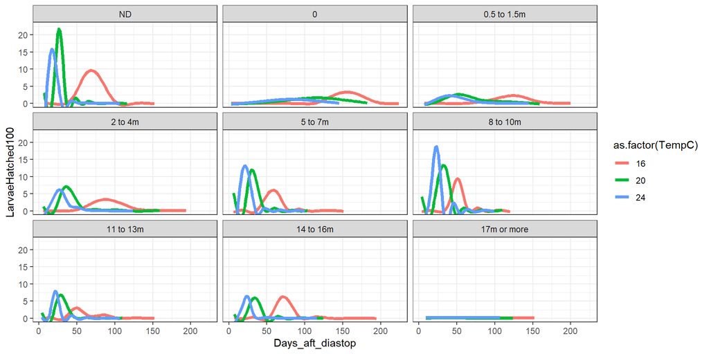

```r
ggplot(datadiap,
       aes(Days_aft_diastop, LarvaeHatched100, color = as.factor(TempC))) +
  #geom_point() + no geom point
  geom_smooth(size = 1.5, se = FALSE) +
  facet_wrap(~DiapMonCat) +
  coord_cartesian(ylim = c(0, 22.5)) +
  theme_bw()
```

### 5.1.2. VersionB

Colorful, 'vik' color palette, renamed labels, special label

[figure not shown]

```r
#relabelling the category names
labelsForDiapmonthcats <- c('ND' = "Non-diapause strain", '0' = "0 month", '0.5 to 1.5m' = "0.5 to 1.5 months", '2 to 4m' = "2 to 4 months", '5 to 7m' = "5 to 7 months", '8 to 10m' = "8 to 10 months", '11 to 13m' = "11 to 13 months", '14 to 16m' = "14 to 16 months", '17m or more' = "17 or more months" )

#special label for the ideal, 8 to 10 months category
labelNDL <- data.frame(Days_aft_diastop = 142,
                       LarvaeHatched100 = 20,
                       DiapMonCat = "8 to 10m",
                       label = "Natural Diapause Length")

ggplot(datadiap,
       aes(Days_aft_diastop, LarvaeHatched100)) +
  geom_smooth(aes(color = as.factor(TempC)), size = 1.5, se = FALSE) +
  facet_wrap(~DiapMonCat, labeller = labeller(DiapMonCat = labelsForDiapmonthcats)) +
  coord_cartesian(ylim = c(0, 22.5)) +
  labs(
    x ="Days after diapause stopped",
    y = "Hatched larvae per 100 overwintered eggs",
    color = ""
  ) +
  #theme_bw(base_size = 22) +
   theme(legend.title = element_blank(),
         text = element_text(size = 36, face = "bold", family = "arial"),
        strip.background = element_rect(colour = "black", fill = "grey90"),
         panel.background = element_rect(fill = NA),
         panel.grid.major = element_line(colour = "grey80"),
         panel.grid.minor = element_line(color = "grey70"),
         axis.title.y = element_text(margin = margin(r = +20)),
         axis.title.x = element_text(margin = margin(t = +20)),
         axis.text.x = element_text(size = 12),
         panel.border = element_rect(color = "black", fill = NA, size = 1)
   ) +
  scale_color_manual(values = scico(3, begin = 0.1, palette = "vik"), labels = c(
    "  16 戼㸰C", "  20 戼㸰C", "  24 戼㸰C"
  )) +
  scale_x_continuous(#minor_breaks = seq(0 , 300, 14),
  breaks = seq(0, 300, 14)) +
  geom_label(data = labelNDL, aes(label = label),
             size = 5)
```

### 5.1.3. VersionC

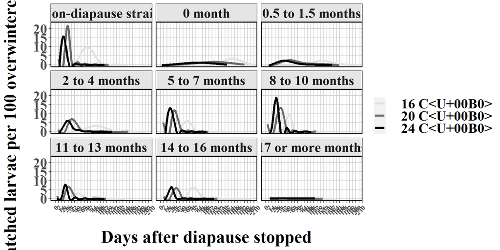

```r
labelsForDiapmonthcats <- c('ND' = "Non-diapause strain", '0' = "0 month", '0.5 to 1.5m' = "0.5 to 1.5 months", '2 to 4m' = "2 to 4 months", '5 to 7m' = "5 to 7 months", '8 to 10m' = "8 to 10 months", '11 to 13m' = "11 to 13 months", '14 to 16m' = "14 to 16 months", '17m or more' = "17 or more months" )

ggplot(datadiap,
       aes(Days_aft_diastop, LarvaeHatched100, color = as.factor(TempC))) +
  geom_smooth(size = 1.5, se = FALSE) +
  facet_wrap(~DiapMonCat, labeller = labeller(DiapMonCat = labelsForDiapmonthcats)) +
  coord_cartesian(ylim = c(0, 22.5),
                  xlim = c(0, 200)) +
  labs(
           x ="Days after diapause stopped",
           y = "Hatched larvae per 100 overwintered eggs",
           color = ""
          ) +
  theme(legend.title = element_blank(),
        text = element_text(size = 25, face = "bold", family = "serif"),
        strip.background = element_rect(colour = "black", fill = "grey90"),
        panel.background = element_rect(fill = NA),
        panel.grid.major = element_line(colour = "grey80"),
        axis.title.y = element_text(margin = margin(r = +20)),
        axis.title.x = element_text(margin = margin(t = +20)),
        axis.text.x = element_text(angle = 45, hjust = 1, size = 10),
        panel.border = element_rect(color = "black", fill = NA, size = 1)
        ) +
 scale_color_manual(values = scico(3, begin = 0.1, palette = "grayC"), labels = c(
  "  16 C戼㸰", "  20 C戼㸰", "  24 C戼㸰"
 )) +
scale_x_continuous(breaks = seq(0,300, by = 7))
```

```r
#ggsave("Fig1.jpg", width = 66, height = 33, units = c("cm")) #optional dimensions for saving out the image
```

### 5.1.4. VersionD

This version follows the requirements of the Entomologia experimentalis et applicata journal. Black and white, renamed labels, printable.

[figure not shown]

```r
labelsForDiapmonthcats <- c('ND' = "Non-diapause strain", '0' = "0 month", '0.5 to 1.5m' = "0.5 to 1.5 months", '2 to 4m' = "2 to 4 months", '5 to 7m' = "5 to 7 months", '8 to 10m' = "8 to 10 months", '11 to 13m' = "11 to 13 months", '14 to 16m' = "14 to 16 months", '17m or more' = "17 or more months" )

labelNDL <- data.frame(Days_aft_diastop = 142,
                       LarvaeHatched100 = 20,
                       DiapMonCat = "8 to 10m",
                       label = "Natural Diapause Length")

ggplot(datadiap,
       aes(Days_aft_diastop, LarvaeHatched100)) +
  geom_smooth(aes(linetype = as.factor(TempC)), size = 2.2, se = FALSE, color = "black") +
  facet_wrap(~DiapMonCat, labeller = labeller(DiapMonCat = labelsForDiapmonthcats)) +
  coord_cartesian(ylim = c(0, 22.5)) +
  labs(
    x ="Post-diapause incubation(days)",
    y = "Hatched larvae/100 overwintered eggs"
  ) +
  theme(
    text = element_text(size = 36, family = "arial"),
    axis.title.y = element_text(margin = margin(r = +20)),
    strip.background = element_rect(colour = "black", fill = "white"),
    panel.background = element_rect(fill = NA),
    panel.grid.major = element_line(colour = "grey80"),
    panel.border = element_rect(color = "black", fill = NA, size = 0.5),
    axis.text.x = element_text(size = 24, angle = 90, vjust = 0.5, hjust=1),
    legend.title=element_blank(),
    axis.title.x = element_text(margin = margin(t = +20)),
    legend.key.width = unit(1.5, "cm"),
    legend.key.height = unit(1, "cm")) +
  scale_x_continuous(breaks = seq(0, 300, 14)) +
  #geom_label(data = labelNDL, aes(label = label),
   #          size = 8) +
  scale_linetype_manual(values=c("solid", "twodash" ,"dotted"))
```

```r
#ggsave("Fig1.jpg", width = 50, height = 26, units = c("cm")) #optional dimensions for saving out the image
```

## 5.2. Figure 2.

4 subplot (hatching peak, start, duration and end) to one - ggarange method - for publication, printable and bw. Please note that in the publication the lines and the rhombus shapes are in black color!

### 5.2.1 VersionA

[figure not shown]

```r
pDur <- treylevelplot(hatchduration) + NDpoint +
labs(
    y = "Hatching duration in days "
  ) + theme(legend.position = "none")

pStart <- treylevelplot(hatchstart) + NDpoint +
  labs(
    y = "Days until hatching start"
  ) + theme(legend.position = "none")
pPeak <- treylevelplot(hatchpeak) + NDpoint +
  labs(
    y = "Days until hatching peak"
  ) + theme(legend.position = "none")

pEnd <- treylevelplot(hatchend) + NDpoint +
  labs(
    y = "Days until hatching end"
  ) + theme(legend.position = "none")


ggarrange(pDur, pStart, pPeak, pEnd, ncol= 2, nrow = 2)
```

```r
#ggsave("Fig2mod.jpg", width = 60, height = 34, units = c("cm")) #optional to save out the image
```

## 5.3. Figure 3.

This graph are will containing two plots in one: a) egg overwinter survival (pOW2) b) egg hatching percentages (pHatchR).

## 5.3.1. Creating the a) part as the overwintering survival

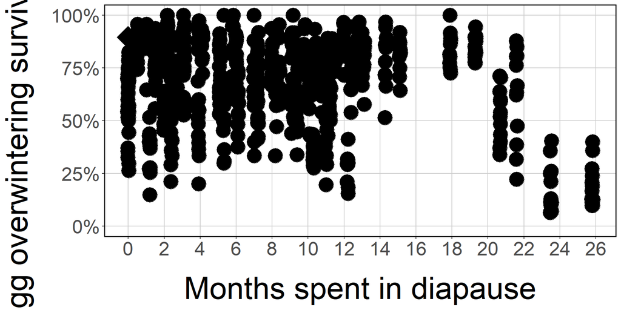

```r
traytableNoND <- traytable %>%
  filter(EggOrigin == "CSE") #ND eggs are exluded here

pOW2 <- ggplot(traytableNoND,
            aes(DiapMonths, OverwintSurv)) +
  geom_point(color = "black",  size = 8, position = "jitter") +
  geom_point(aes(y = OverwintSurvAvg),
             data = filter(survdata, EggOrigin == "ND"),
             color = "black", size = 12, shape = 18) +
  scale_x_continuous(breaks = scalebreakx) +
  scale_y_continuous(labels = scales::percent_format(),
                     breaks = c(0, 0.25, 0.50, 0.75 , 1.0)) +
  theme(
        legend.position = "none",
        text = element_text(size = 28, family = "arial"),
        panel.background = element_rect(fill = NA),
        panel.grid.major = element_line(colour = "grey80"),
        axis.title.y = element_text(margin = margin(r = +20)),
        axis.title.x = element_text(margin = margin(t = +20)),
        panel.border = element_rect(color = "black", fill = NA, size = 1),
   axis.title=element_text(size = 36)) +
   labs(x ="Months spent in diapause",
        y = "Egg overwintering survival (%)",
        color = "") +
  expand_limits(y = 0)
pOW2
```

```r
#ggsave("Fig3A.jpg", width = 50, height = 25, units = c("cm"))
```

## 5.3.2. Creating the b) part as the hatching percentages

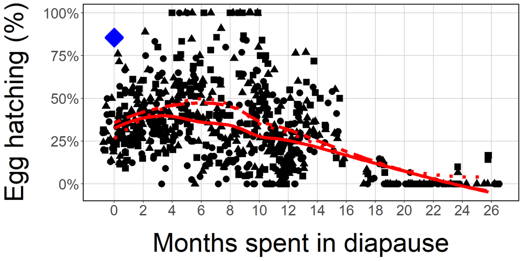

```r
pHatchR <- treylevelplot(hatchratio) + NDpoint +
  scale_y_continuous(labels = function(x) paste0(x*1, "%")) +
  theme(
        text = element_text(size = 28, family = "arial"),
        panel.background = element_rect(fill = NA),
        panel.grid.major = element_line(colour = "grey80"),
        axis.title.y = element_text(margin = margin(r = +20)),
        axis.title.x = element_text(margin = margin(t = +20)),
        panel.border = element_rect(color = "black", fill = NA, size = 1),
        legend.title = element_blank(),
        legend.position = "none",
        axis.text.y = element_text(size = 20),
        axis.text.x = element_text(size = 20),
        legend.key.width = unit(1.5, "cm"),
        legend.key.height = unit(1, "cm"),
        axis.title=element_text(size = 36)) +
   labs(x ="Months spent in diapause",
        y = "Egg hatching (%)",
        color = "") +
  expand_limits(y = 100)
pHatchR
```

```r
#ggsave("Fig3B.jpg", width = 50, height = 25, units = c("cm")) #optional, for saving the image
```

## 5.3.3. Combining the two parts

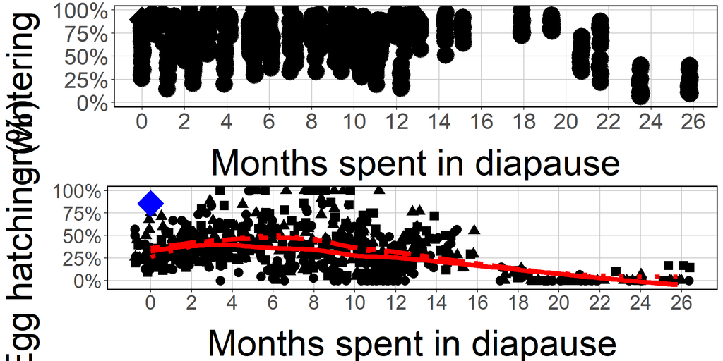

```r
ggarrange(pOW2, pHatchR,
          ncol = 1, nrow = 2)
```

```r
#ggsave("Fig3Comb.jpg", width = 50, height = 25, units = c("cm"))
```